# phylogram: Dendrograms for Evolutionary Analysis

Shaun P. Wilkinson *<sup>1</sup>* and Simon K. Davy *<sup>1</sup>

*<sup>1</sup>* School of Biological Sciences, Victoria University of Wellington, Kelburn Parade, Wellington, New Zealand 6012

* Correspondence author. E-mail: shaunpwilkinson@gmail.com

## Abstract

The **phylogram** R package contains functions for developing evolutionary trees as deeply-nested lists known as “dendrogram” objects. It provides functions for importing and exporting trees in parenthetic text format, several tools for command-line tree manipulation, and functions for converting trees between “dendrogram” and “phylo” class objects. The **phylogram** package is released under the GPL-3 license, and is available for download from CRAN https://CRAN.R-project.org/package=phylogram and github https://github.com/shaunpwilkinson/phylogram.  
**Contact:** shaunpwilkinson@gmail.com

## Introduction

The R environment continues to gain popularity as a platform for working with evolutionary trees, due to the reproducible code-based workflow and the many powerful analytical tools available in a suite of open-source packages such as **ape** (Paradis *et al.*, 2004), **phangorn** (Schliep, 2011) and **Phytools** (Revell, 2012). These packages typically employ a tree structure known as the “phylo” object, whose primary element is an integer matrix with one row for each edge in the graph, and two columns giving the indices of the connecting nodes. This is a highly versatile and memory-efficient format suitable for most applications encountered by evolutionary biologists.

An alternative tree structure is the “dendrogram” object, generated using the `as.dendrogram` function in the **stats** package (R Core Team, 2017). Rather than a matrix of edges, a dendrogram is a hierarchical list. These ‘lists of lists’ can be deeply nested, with the limit depending on the C stack size (settable *via* `options("expressions")`). A useful feature of this representation is its modularity, whereby the sub tree of a tree is itself a tree - a dendrogram within a dendrogram. This means that dendrogram objects are subsettable in the same way that standard lists are, which in addition to the inbuilt editing functions such as `cut` and `merge`, facilitates intuitive command-line tree manipulation. An especially powerful feature of this object type is that tree editing operations can be carried out recursively using fast inbuilt functions in the “apply” family such as `dendrapply` and `lapply`.

Each node of a dendrogram object has the following mandatory attributes:

- “height” the position of the node along the vertical axis (assuming the graph is orientated vertically)
- “midpoint” the horizontal distance of the node from the left-most member of the sub tree (where the horizontal distance between adjacent leaves is 1 unit)
- “members” the number of terminal leaf nodes belonging to the node
- “class” all nodes have the class attribute “dendrogram”

Rather than lists, terminal leaf nodes are length-1 integer vectors whose values correspond to the indices of the members in the set. The “members” attributes of leaf nodes is always 1, the “midpoint” attribute is 0, and they have two additional attributes:

- “leaf” TRUE for terminal nodes (NULL otherwise)
- “label” an optional character string giving the name of the taxon or group

Aside from those listed above, users may attach other objects as attributes to the dendrogram nodes. For example, “label” attributes can be attached to inner nodes, and users can specify plotting parameters for each node by setting the attributes “nodePar” and “edgePar”.

While generally not as memory efficient as “phylo” objects, the flexibility, modularity and intuitive structure of dendrogram objects are appealing to many users, partiularly where highly dynamic tree structures are required for applications such as machine learning clustering and classification.

#### Example 1: Building a dendrogram object manually

Consider the simple example of a tree with three members named “A”, “B” and “C”, where “B” and “C” are more closely related to each other than they are to “A”. An unweighted Newick string for this tree would be *(A,(B,C));* We can manually create a dendrogram object for this basic phylogeny and plot the tree as follows:

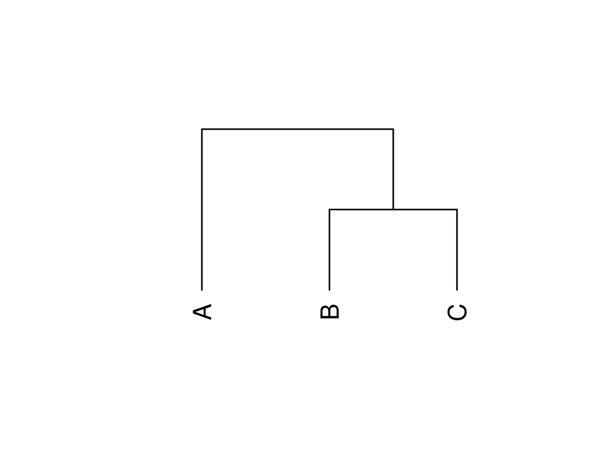

```r
x <- list(1, list(2, 3))
## attach "leaf" and "label" attributes to leaf nodes
attr(x[[1]], "leaf") <- TRUE
attr(x[[2]][[1]], "leaf") <- attr(x[[2]][[2]], "leaf") <- TRUE
attr(x[[1]], "label") <- "A"
attr(x[[2]][[1]], "label") <- "B"
attr(x[[2]][[2]], "label") <- "C"
## set "height" attributes for all nodes
attr(x, "height") <- 1
attr(x[[1]], "height") <- 0
attr(x[[2]], "height") <- 0.5
attr(x[[2]][[1]], "height") <- attr(x[[2]][[2]], "height") <- 0
## set "midpoints" attributes for all nodes
attr(x, "midpoint") <- 0.75
attr(x[[1]], "midpoint") <- 0
attr(x[[2]], "midpoint") <- 0.5
attr(x[[2]][[1]], "midpoint") <- attr(x[[2]][[2]], "midpoint") <- 0
## set "members" attributes for all nodes
attr(x, "members") <- 3
attr(x[[1]], "members") <- 1
attr(x[[2]], "members") <- 2
attr(x[[2]][[1]], "members") <- attr(x[[2]][[2]], "members") <- 1
## set class as "dendrogram"
## Note that setting the class for the root node
## automatically sets the class of all nested subnodes
class(x) <- "dendrogram"

### plot the dendrogram
plot(x, yaxt = "n")
```

**Figure 1:** A simple dendrogram with three terminal leaf nodes

As demonstrated in this example, manually setting attributes on dendrogram objects can be rather tedious, motivating the development of functions to automate the generation and manipulation of these tree structures.

## The ‘phylogram’ package

### Importing and exporting trees

The Newick (a.k.a. New Hampshire) parenthetic text format (Felsenstein *et al.*, 1986) is a universal phylogenetic tree representation that is compatible with most tree-editing software. The **phylogram** package features the text parser `read.dendrogram` that reads a character string or text file in the Newick format and creates a dendrogram object. This function supports weighted edges, labels with special meta-characters (enclosed in single quotation marks), comments (enclosed in square brackets; ignored by the parser), multifuricating nodes, and both rooted and unrooted trees. Inner-node labels are currently ignored; however, the inclusion of “label” attributes for non-leaf nodes will be available in a future version. Objects of class “dendrogram” can be exported as Newick-style parenthetic text using the function `write.dendrogram`.

#### Example 2: Import and export a tree from a Newick string

The simple Newick string in Example 1 can be imported as a dendrogram object using the `read.dendrogram` function as follows:

```r
library(phylogram)
newick <- "(A,(B,C));"
x <- read.dendrogram(text = newick)
x
```

```
#> 'dendrogram' with 2 branches and 3 members total, at height 2
```

The following command writes the object back to the console in Newick format without edge weights:

```r
write.dendrogram(x, edges = FALSE)
```

```
#> [1] "(A,(B,C));"
```

The syntax is similar when reading and writing text files, except that the `text` argument is replaced by `file`, and a valid file path is passed to the function.

If required, the dendrogram can be converted to an object of class “phylo” using the `as.phylo.dendrogram` method, and converted back to a dendrogram with `as.dendrogram.phylo`.

```r
y <- as.phylo(x)
z <- as.dendrogram(y)
identical(x, z)
```

```
#> [1] TRUE
```

### Tree vizualization

Publication-quality trees can be generated from dendrogram objects using the **stats** plotting function `plot.dendrogram`, and the extensive plotting functions available in dendrogram-enhancing packages such as **circlize** (Gu *et al.*, 2014) and **dendextend** (Galili, 2015). The latter also offers the facility to convert dendrograms to “ggdend” objects, for which many powerful ‘grammar of graphics’ plotting functions are available in the **ggplot2** (Wickham, 2009) and **ggdendro** (DeVries and Ripley, 2016) packages. Moreover, there are several advanced plotting options for “phylo” objects in the **ape** package (Paradis *et al.*, 2004), as well as the Bioconductor package **ggtree** (Yu *et al.*, 2017). Given the extensive tree visualization options already available, we do not include any additional plotting functions in the **phylogram** package.

### Summary

The **phylogram** package offers a high quality tree parser, several new dendrogram-editing functions, and a bridge between the dendrogram and phylo object types, thus improving access to comprehensive number of object-specific functions found across a suite of contributed packages. Future versions of the package will aim to further expand the range of input text formats and object types available, further facilitating access to a wide variety of bioinformatic applications available in the R programming language. This software is still under active development, and will continue to be upgraded and expanded as new applications arise. Bug reports and other feedback are welcomed and can be directed to the GitHub issues page at http://github.com/shaunpwilkinson/phylogram/issues, or the **phylogram** google group at https://groups.google.com/group/phylogram.

## Acknowledgements

This software was developed with funding from a Rutherford Foundation Postdoctoral Research Fellowship from the Royal Society of New Zealand. The authors declare no competing interests.

## Author Contributions

Both authors conceived and designed the software. SPW wrote the package functions and documentation. Both authors wrote the manuscript and gave final approval for publication.

## References

DeVries,A. and Ripley,B.D. (2016) ggdendro: create dendrograms and tree diagrams using ’ggplot2’.

Felsenstein,J. *et al.* (1986) The newick tree format, 1986.

Galili,T. (2015) dendextend: An R package for visualizing, adjusting and comparing trees of hierarchical clustering. *Bioinformatics*, **31**, 3718–3720.

Gu,Z. *et al.* (2014) circlize implements and enhances circular visualization in R. *Bioinformatics*, **30**, 2811–2812.

Paradis,E. *et al.* (2004) APE: analyses of phylogenetics and evolution in R language. *Bioinformatics*, **20**, 289–290.

R Core Team (2017) R: A Language and Environment for Statistical Computing.

Revell,L.J. (2012) phytools: an R package for phylogenetic comparative biology (and other things). *Methods in Ecology and Evolution*, **3**, 217–223.

Schliep,K.P. (2011) phangorn: phylogenetic analysis in R. *Bioinformatics*, **27**, 592–593.

Wickham,H. (2009) ggplot2: Elegant Graphics for Data Analysis Springer-Verlag, New York.

Yu,G. *et al.* (2017) ggtree: an R package for visualization and annotation of phylogenetic trees with their covariates and other associated data. *Methods in Ecology and Evolution*, **8**, 28–36.